# Olympic Athlete Medal Prediction: A Statistical Analysis

Aadi Bhandary, Alvin Do, Milan Patel

12/15/2024

## Introduction

Athletes from around the world compete at the highest levels at the Olympic Games. This analysis uses a comprehensive dataset spanning 120 years of Olympic history to explore a fundamental question: **What factors contribute to an athlete winning a medal?**

Our Athlete Events dataset originates from the [Kaggle Olympic dataset](https://www.kaggle.com/datasets/heesoo37/120-years-of-olympic-history-athletes-and-results?resource=download) and provides a repository of information about Olympic participants, including their physical characteristics, age, and sport. By focusing on male athletes in Summer Olympic Games from 2004 onwards, we aim to develop a predictive model that can help understand the key determinants of Olympic success.

The primary goal of this research is to construct a robust statistical model that can predict whether an athlete is likely to win a medal based on attributes such as height, weight, and age. This model could provide valuable insights for athletes and coaches in understanding the physiological factors that might influence Olympic performance.

## Methods

### Data Preparation

We began by preprocessing the Olympic Athletes Events dataset with several key steps:

1. **Data Filtering**:
   - Selected only Summer Olympic Games
   - Focused exclusively on male athletes
   - Restricted data to games from 2004-onwards
2. **Data Cleaning**:
   - Removed entries with missing height, weight, or age data
   - Created a binary “Podium” variable (1 for medal winners, 0 for non-medalists)
3. **Data Splitting**:
   - Utilized an 80-20 train-test split for model development and validation

The code below shows the data cleansing process we used for our analysis.

```r
library(readr)
dat = read.csv("./athlete_events.csv")
summer_games_data = dat[dat["Season"] == "Summer",]
summer_games_data = summer_games_data[summer_games_data["Sex"] == "M",]
summer_games_data = summer_games_data[summer_games_data["Year"] >= 2004,]
summer_games_data = summer_games_data[!is.na(summer_games_data$Height),]
summer_games_data = summer_games_data[!is.na(summer_games_data$Weight),]
summer_games_data = summer_games_data[!is.na(summer_games_data$Age),]
summer_games_data$Podium = ifelse(is.na(summer_games_data$Medal), 0, 1)
```

Our rules may be considered narrow since the data set spans many years and have a variety of options for predictors, however we find that an accurate predictor should be without structural error. The first error we wanted to avoid was bimodality: where there are two distributions tied to our predictors, the obvious culprit being sex. Below is a graph of the distribution of heights.

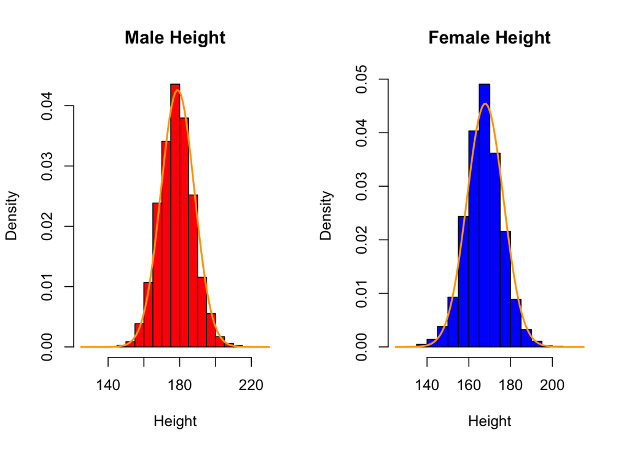

We could overcome this bimodality by including sex as a categorical predictor, however our goal is to abstract a general functional relationship between our predictors and medal odds. Including sex adds no new meaning if it just shifts the curve with the same linear relationships.

Another data cleansing item that we included was reducing the number of years.

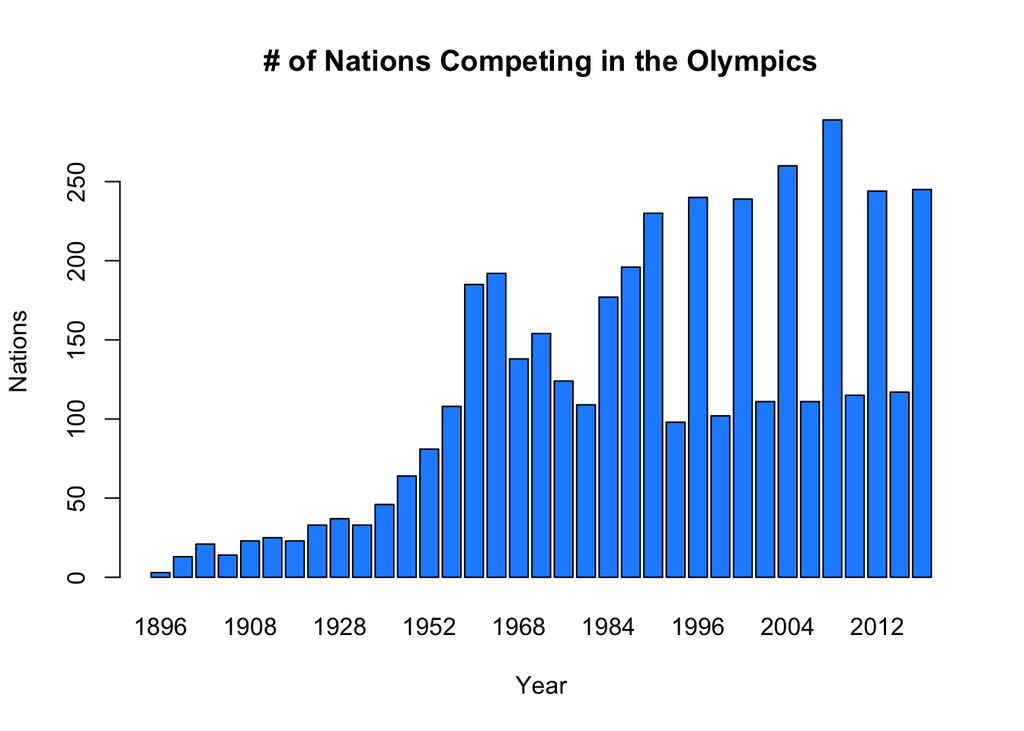

The general trend is that as the years go on, the number of participating nations increases. You may notice that the plot above has a substantial number of dips in between the years sampled. This can easily be explained by the winter games having a smaller number of participating nations in the games.

Below is a plot that of the number of participating athletes split by the winter and summer games over the years.

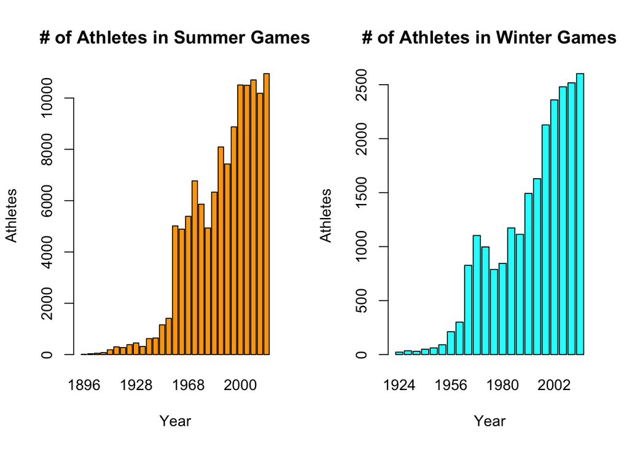

As we can see, there is a substantially smaller number of winter games participants than there are summer games, but the general trend of increasing athlete participation holds true. Therefore, it is in our interest to factor in the most recent years of data for our study since the rate of change in the number of athletes levels off in that time period.

Lastly, there may be a significant bias tied to the nations of origin (the `Team` column in the dataset), which may be a noisy categorical predictor when trying to build a general predictor for podium odds. Below is a plot of the medals by nation.

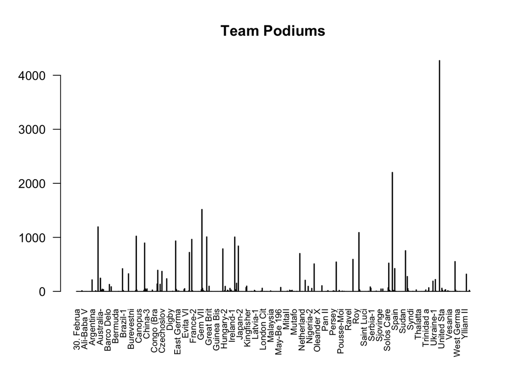

Based on the plot above, it is apparent that larger and more developed countries (China and The United States) can be over represented in the podium variable. Although one can argue “being an American” increases your odds of achieving a medal, this makes for a poor conclusion and adds no value to creating a generalized predictor. Furthermore, cleaning this column for noisy labels like “February” is difficult.

After data cleansing, our final bulk data set size is 29,717 observations. Predictors: `Sex`, `Year`, and `Team` don’t offer us the explanation we are seeking in our problem statement, hence we have decide to omit them. Our goal now is to figure out what is the relationship between basic biological predictors for predicting podium probability.

### Modeling Approach

In order to accurately test the hypotheses we developed, we must first establish a standard that our models can be compared to. The first is accuracy and the second is RMSE.

Below is the formula for Accuracy: $Accuracy = \frac{\sum_{i = 1}^{1000}Correct}{\sum_{i = 1}^{1000}Test Length}$

Below is the formula for RMSE (where i is one of 1000 iterations: $RMSE_i = \sqrt{\sum_{j = 1}^{Test Length}\frac{(\hat{y}-y)^2}{Test Length}}$

1. **Basic Model**:
   - Predictors: Height, Weight, Age
   - Simple linear relationship with medal probability where the sign of our prediction indicates achieving a podium.
2. **Basic Logistic Model**:
   - Predictors: Height + Weight + Age
   - A logistic regression where Podium is our logits
3. **Interaction Model**:
   - Predictors: Height * Weight + Age
   - A logistic regression that explores potential interactive effects between physical attributes
4. **Stepwise AIC Model**:
   - Serves to address bias in the parameters we selected in the case that we are fundamentally wrong.
   - Used automated model selection with Akaike Information Criterion (AIC)
   - Considered additional predictors like Sport and interaction terms
   - Employed bidirectional selection to identify the most parsimonious model

## Results

Below are plots and tables that show the performance of our models.

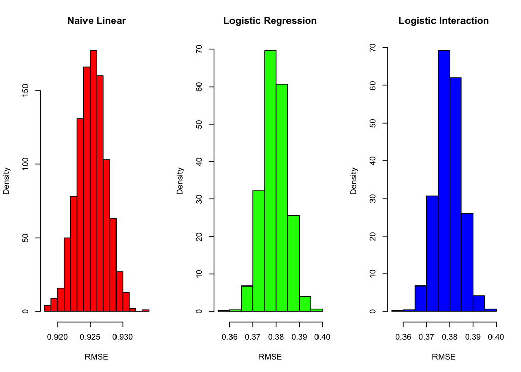

| Model | AVG_RMSE | ACC |
| --- | --- | --- |
| Naive Linear | 0.9252 | 0.1440 |
| Logistic Regression | 0.3794 | 0.8560 |
| Logistic Interaction | 0.3796 | 0.8559 |

### Model Performance Comparison

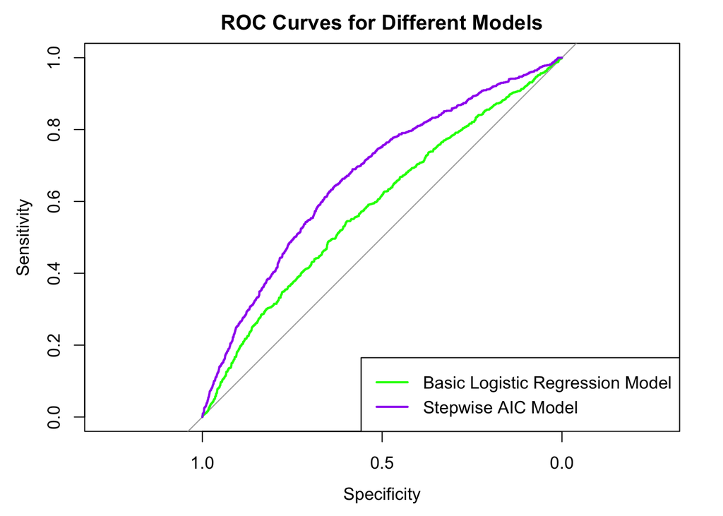

### Selected Model

The Stepwise AIC model emerged as our preferred approach, incorporating:

- Height
- Weight
- Age
- Sport (as a factor)
- Interaction terms between `Weight:Age` and `Height:Age`

## Discussion

```
## Analysis of Deviance Table
##
## Model 1: Podium ~ Age + Height + Weight
## Model 2: Podium ~ Height * Weight + Age
##   Resid. Df Resid. Dev Df Deviance      F    Pr(>F)
## 1     23769     2908.3
## 2     23768     2903.5  1   4.7531 38.909 4.516e-10 ***
## ---
## Signif. codes:  0 '***' 0.001 '**' 0.01 '*' 0.05 '.' 0.1 ' ' 1
```

## Appendix

Our code is made public at our [Github repo](https://github.com/aadibhandary2001/DataProject) with updated changes as of 2:00pm CST on December 15, 2024.

### Analysis Contributors

- Aadi Bhandary, Alvin Do, Milan Patel